# PalaeoOpen GAM exercise 2

## Model fitting

Before we fit some example models, we need to turn on some extra options for the fitting process. The `nthreads` option will tell `gam()` to use multiple CPU cores on your laptop *if* the *mgcv* package is configured for parallel processing, and the `trace` argument turns on printing of the fitting process so we can see that something is happening if the model takes a while to fit.

```r
# eval: false
ctrl <- gam.control(nthreads = 4, trace = TRUE)
```

```r
# echo: false
ctrl <- gam.control(nthreads = 4, trace = FALSE)
```

The first model we will fit is once where we have

- a smooth of `year` for each pigment, to model the change in the mean, $\mu_j$, concentration for the respective pigment over time,
- a constant term for the Tweedie power parameter $p$; some preliminary exploration suggests that the data do not support anything more complex for $p$, and
- a simgle smooth of `year` for the scale parameter, $\phi$, of the distribution

Together, $\mu$, $p$, and $\phi$ combine to give the conditional variance of the response at any value of `year`, separately for each pigment.

We now fit this model in *mgcv*. Distributional models require a list of formulas, only the first of which have a left-hand side. This is the linear predictor for the mean. The second formula is the linear predictor for $p$, and the third formular the linear predictor for $\phi$. Note I have suppressed all the model `trace` output here, but you will see a lot of gibberish printed to the console as the model fits.

```r
tictoc::tic()
mtwlss0 <- gam(
  list(
    concentration ~ s(year, f_pigment, bs = "fs", k = 10), # mean
                  ~ 1,               # power, intercept only
                  ~ s(year, k = 10)  # scale
  ),
  data = lake227,
  family = twlss,
  optimizer = "efs", # twlss can be more stable w. Extended Fellner Schall
  method = "REML",   # REML smoothness selection
  control = ctrl
)
tictoc::toc()
## 3.069 sec elapsed
```

The `tic()` and `toc()` calls are what will tell you about the the timing of the model fits.

A more complex model would be one that allows each pigment to have a different trend in the scale parameter, $\phi_j$. We fit this model now, which will comprise

- a smooth of `year` for each pigment, to model the change in the mean, $\mu_j$, concentration for the respective pigment over time,
- a constant term for the Tweedie power parameter $p$; some preliminary exploration suggests that the data do not support anything more complex for $p$, and
- a smooth of `year` for each pigment for the scale parameter, $phi_j$, of the distribution

Note that there is less information about the other distributional parameters in the data than there is for the mean. As such, we don’t expect the smooths for $\phi_j$ to be sa complex as the ones for the means $\mu_j$, so we set `k` a little lower than the default (of `10`) in the fit below

```r
tictoc::tic()
mtwlss <- gam(
  list(
    concentration ~ s(year, f_pigment, bs = "fs", k = 10),
                  ~ 1,
                  ~ s(year, f_pigment, bs = "fs", k = 6)
  ),
  data = lake227,
  family = twlss,
  optimizer = "efs", # twlss can be more stable w. Extended Fellner Schall
  method = "REML", # REML smoothness selection
  control = ctrl
)
tictoc::toc()
## 3.299 sec elapsed
```

A crude comparison of the models in terms of predictive performance only is provide by `AIC()` — note that I’m only using this here to show that the more complex model has considerable support over the first mdoel we fitted.

```r
AIC(mtwlss0, mtwlss)
##               df      AIC
## mtwlss0 46.98196 2390.581
## mtwlss  54.16319 2383.968
```

The model summary for the more complex model shows that both sets of smooths are statistically interesting

```r
summary(mtwlss)
##
## Family: twlss
## Link function: log identity identity
##
## Formula:
## concentration ~ s(year, f_pigment, bs = "fs", k = 10)
## ~1
## ~s(year, f_pigment, bs = "fs", k = 6)
##
## Parametric coefficients:
##                 Estimate Std. Error z value Pr(>|z|)
## (Intercept)    5.030e+00  4.659e-01   10.80   <2e-16 ***
## (Intercept).1  6.854e+01  4.452e+14    0.00        1
## (Intercept).2 -3.287e+00  2.713e-01  -12.12   <2e-16 ***
## ---
## Signif. codes:  0 '***' 0.001 '**' 0.01 '*' 0.05 '.' 0.1 ' ' 1
##
## Approximate significance of smooth terms:
##                       edf Ref.df Chi.sq p-value
## s(year,f_pigment)   39.10     49 8757.8  <2e-16 ***
## s.2(year,f_pigment) 12.06     29   77.5  <2e-16 ***
## ---
## Signif. codes:  0 '***' 0.001 '**' 0.01 '*' 0.05 '.' 0.1 ' ' 1
##
## Deviance explained = 97.7%
## -REML = 1227.2  Scale est. = 1         n = 240
```

We should check the model diagnostics, to see if were are consistent with the assumptions of the model — note this plot will take a few seconds to produce as it needs to simulate data from the fitted Tweedie distributions

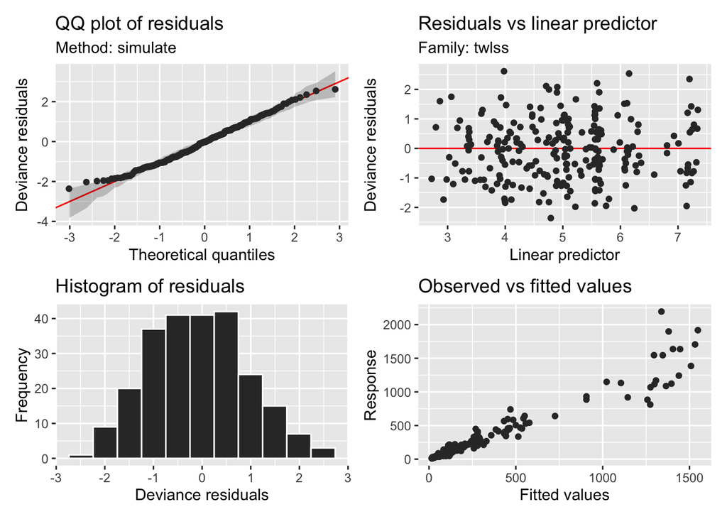

```r
appraise(mtwlss)
```

Nothing seems to untoward here, in fact these diagnostics are pretty good really.

The component smooths, on the link (log) scale are plotting using the `draw()` method:

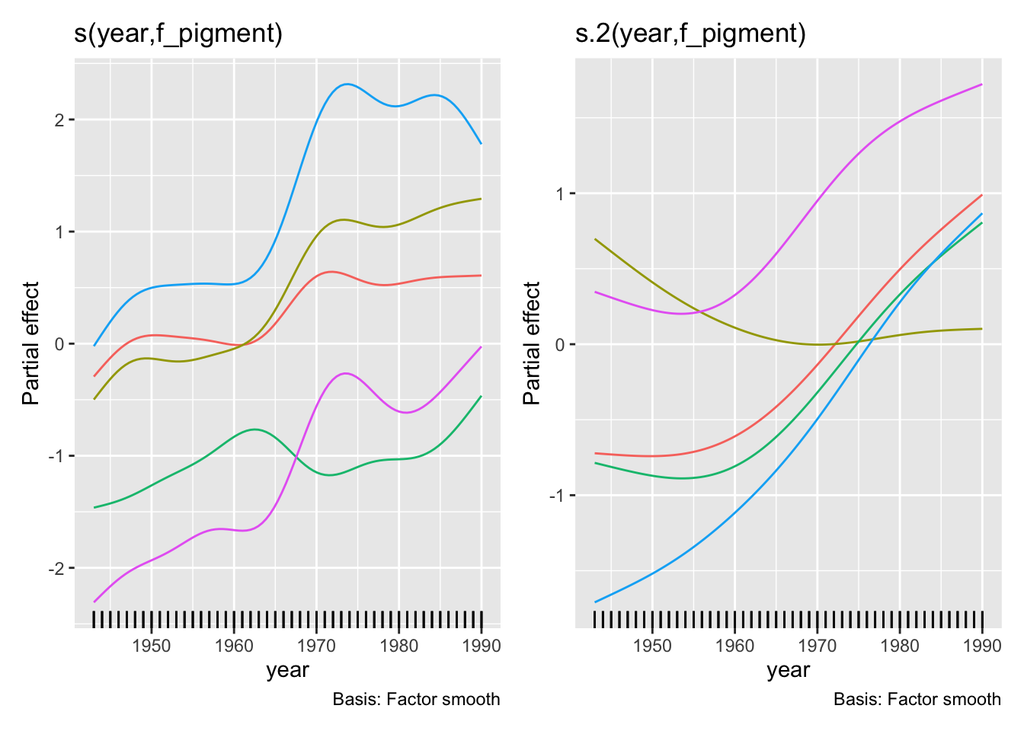

```r
draw(mtwlss)
```

The final diagnostic check we will perform is to look to see if the original basis size was large enough.

```r
k.check(mtwlss)
##                     k'      edf   k-index p-value
## s(year,f_pigment)   50 39.10408 0.4681531       0
## s.2(year,f_pigment) 30 12.05911 0.4681531       0
```

The reported values of `k-index` are all well below 1, suggesting a problem. However, this heuristic test is not designed with time series in mind and unmodelled autocorrelation can cause this test to reject the null hypothsis.

Here, the issue really is unmodelled or residual autocorrelation; handling this will require the use of the new neighbourhood cross validation method of Simon Wood, which we use in fitting via `method = "NCV"` and providing a suitable object to the `nei` argument. This is not something we can do today however, but watch this space; after eight or nine years working on this data set, sporadically, I will soon have a paper ready on the method with the Lake 227 fits as one of the examples demonstrating the technique.

A further task is to convert the estimated smooths into estimated means and variances for each pigment. This requires some non-trivial math to undo the internal parameterisations used by *mgcv*, which thankfully is handled for us by *gratia*, but we restrict ourselves to plotting the trends in the pigment mean concentrations over time.

First, we need a data slice through the original data, such that we will predict at 100 evenly-spaced values of `year`, repeated for each pigment:

```r
ds <- mtwlss |> data_slice(
  year = evenly(year, n = 100),
  f_pigment = evenly(f_pigment)
)
```

Next, we use the `fitted_values()` function to generate model estimates for each parameter of the distribution for each of the data values in `ds`:

```r
fv <- mtwlss |>
  fitted_values(
    data = ds
  )
```

If we look at what is produced

```r
fv
## # A tibble: 1,500 × 6
##     .row .parameter  .fitted      .se .lower_ci .upper_ci
##    <int> <chr>         <dbl>    <dbl>     <dbl>     <dbl>
##  1     1 location   114.     9.52e- 2  137.      94.6
##  2     1 power        1.99   4.45e+14    1.99     1.01
##  3     1 scale        0.0181 5.11e- 1    0.0494   0.00666
##  4     2 location    92.9    1.72e- 1  130.      66.2
##  5     2 power        1.99   4.45e+14    1.99     1.01
##  6     2 scale        0.0751 5.11e- 1    0.205    0.0276
##  7     3 location    35.4    9.16e- 2   42.4     29.6
##  8     3 power        1.99   4.45e+14    1.99     1.01
##  9     3 scale        0.0170 5.08e- 1    0.0461   0.00629
## 10     4 location   150.     6.06e- 2  168.     133.
## # ℹ 1,490 more rows
```

we see a `.parameter` variable that indicates to which parameter of the distribution each fitted value pertains. We will use the `location` values as these are the ones for the mean, $\mu_j$.

We filter to just the location parameter, bind on the covariate values we predicted at, and then plot the estimated pigment concentrations over time, with a credible interval:

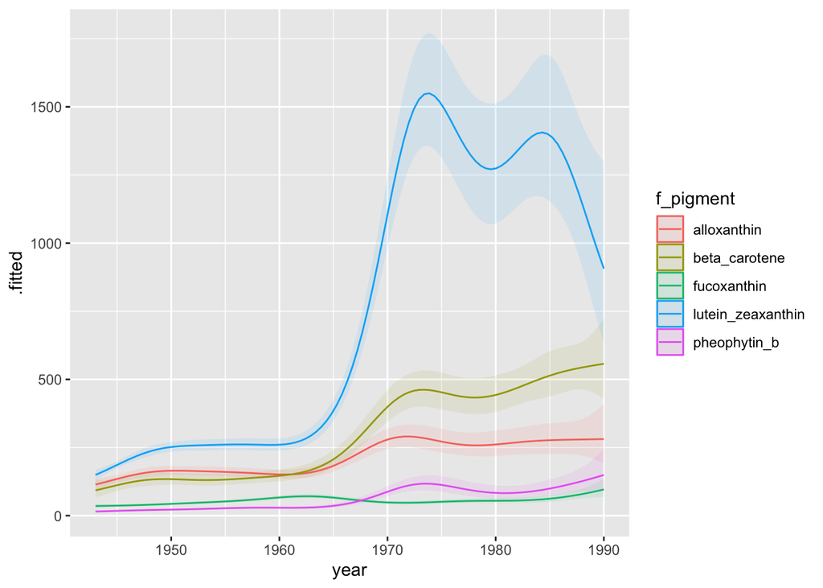

```r
fv |>
  filter(.parameter == "location") |> # only conditional means
  bind_cols(ds) |> # bind on covariate values predicted at
  ggplot(          # plot
    aes(x = year, y = .fitted, colour = f_pigment)
  ) +
    geom_ribbon(   # credible interval
      aes(
        ymin = .lower_ci, max = .upper_ci,
        fill = f_pigment, colour = NULL
      ),
      alpha = 0.1
    ) +
    geom_line()    # fitted values
```

#### References

Cottingham, K.L., Rusak, J.A., Leavitt, P.R., 2000. Increased ecosystem variability and reduced predictability following fertilisation: Evidence from palaeolimnology. Ecol. Lett. 3, 340–348. https://doi.org/10.1046/j.1461-0248.2000.00158.x